# Prédiction de la consommation énergétique et des émissions de CO₂ des bâtiments non résidentiels de Seattle

## 1. Contexte du projet

La ville de Seattle met à disposition des données de benchmarking énergétique sur les bâtiments.  
L’objectif de ce projet est d’exploiter ces données afin de mieux comprendre et prédire :

- la consommation énergétique totale des bâtiments,
- les émissions totales de CO₂ associées.

L’étude porte uniquement sur les **bâtiments non résidentiels**, conformément à l’énoncé du projet.

## 2. Objectif du notebook

L’objectif de ce notebook est de construire une démarche complète de data science pour prédire deux variables cibles :

- `SiteEnergyUse(kBtu)` : consommation énergétique totale,
- `TotalGHGEmissions` : émissions totales de CO₂.

Pour cela, nous allons :

1. charger et comprendre les données ;
2. nettoyer le dataset et définir le bon périmètre d’étude ;
3. analyser les variables et leurs relations ;
4. créer de nouvelles variables pertinentes ;
5. comparer plusieurs modèles de régression ;
6. tester également un modèle **multi-output** capable de prédire les deux cibles simultanément ;
7. interpréter les résultats obtenus.

## 3. Nature du problème

Il s’agit d’un problème de **régression supervisée**.

- **Régression**, car les deux cibles à prédire sont des variables numériques continues.
- **Supervisée**, car les valeurs réelles des cibles sont déjà présentes dans le jeu de données, ce qui permet d’entraîner et d’évaluer des modèles.

Même si les deux cibles sont liées, elles ne représentent pas exactement le même phénomène.  
Nous adopterons donc une double démarche :

- une approche **cible par cible** pour comparer précisément les performances,
- une approche **multi-output** pour tester un modèle unique prédisant l’énergie et le CO₂ en même temps.

## 4. Organisation de l’analyse

Le notebook est organisé selon les grandes étapes suivantes :

1. chargement et inspection des données ;
2. nettoyage et filtrage du périmètre ;
3. analyse exploratoire des variables ;
4. étude des relations entre variables et entre les deux cibles ;
5. feature engineering ;
6. préparation des données pour la modélisation ;
7. comparaison de modèles mono-sortie ;
8. test d’un modèle multi-output ;
9. interprétation et conclusion.

## 5. Import des bibliothèques

Nous commençons par importer les bibliothèques nécessaires pour :

- manipuler les données ;
- visualiser les distributions et relations entre variables ;
- préparer les données pour la modélisation ;
- entraîner et évaluer plusieurs modèles de régression ;
- interpréter les résultats.

```python
import warnings
warnings.filterwarnings("ignore")

import numpy as np
import pandas as pd

import matplotlib.pyplot as plt
import seaborn as sns

from folium import Map
from folium.plugins import HeatMap

from sklearn.compose import ColumnTransformer
from sklearn.pipeline import Pipeline
from sklearn.preprocessing import LabelEncoder, OneHotEncoder, StandardScaler
from sklearn.impute import SimpleImputer

from sklearn.model_selection import train_test_split, cross_validate, GridSearchCV
from sklearn.metrics import mean_absolute_error, mean_squared_error, r2_score

from sklearn.dummy import DummyRegressor
from sklearn.linear_model import LinearRegression, Ridge
from sklearn.ensemble import RandomForestRegressor, ExtraTreesRegressor
from sklearn.multioutput import MultiOutputRegressor
from sklearn.inspection import permutation_importance
from sklearn.svm import SVR
from sklearn.neighbors import KNeighborsRegressor


try:
    from xgboost import XGBRegressor
    XGBOOST_AVAILABLE = True
except ImportError:
    XGBOOST_AVAILABLE = False

RANDOM_STATE = 42

sns.set_theme(style="whitegrid")
pd.set_option("display.max_columns", None)
```

# Analyse Exploratoire

## 6. Chargement du jeu de données

Nous chargeons maintenant le jeu de données de benchmarking énergétique de Seattle.

L’objectif de cette étape est de :

- vérifier que les données sont bien accessibles ;
- observer la taille du dataset ;
- visualiser les premières lignes ;
- identifier les types de variables et la présence éventuelle de valeurs manquantes.

```python
building_consumption = pd.read_csv("2016_Building_Energy_Benchmarking.csv")

building_consumption.shape
```

```
(3376, 46)
```

**Interprétation :**

La commande `shape` permet de connaître la dimension brute du dataset.

- Le nombre de lignes correspond au nombre de bâtiments observés.
- Le nombre de colonnes correspond au nombre de variables disponibles.

Le dataset contient 3376 observations et 46 variables. Chaque ligne correspond à un bâtiment, et chaque colonne correspond à une caractéristique ou une mesure liée à ce bâtiment.

Cette information est importante pour suivre ensuite l’impact des différentes étapes de nettoyage et de filtrage.

```python
# On regarde comment un batiment est défini dans ce jeu de données
building_consumption.head()
```

|  | OSEBuildingID | DataYear | BuildingType | PrimaryPropertyType | PropertyName | Address | City | State | ZipCode | TaxParcelIdentificationNumber | CouncilDistrictCode | Neighborhood | Latitude | Longitude | YearBuilt | NumberofBuildings | NumberofFloors | PropertyGFATotal | PropertyGFAParking | PropertyGFABuilding(s) | ListOfAllPropertyUseTypes | LargestPropertyUseType | LargestPropertyUseTypeGFA | SecondLargestPropertyUseType | SecondLargestPropertyUseTypeGFA | ThirdLargestPropertyUseType | ThirdLargestPropertyUseTypeGFA | YearsENERGYSTARCertified | ENERGYSTARScore | … |
| --- | --- | --- | --- | --- | --- | --- | --- | --- | --- | --- | --- | --- | --- | --- | --- | --- | --- | --- | --- | --- | --- | --- | --- | --- | --- | --- | --- | --- | --- | --- |
| 0 | 1 | 2016 | NonResidential | Hotel | Mayflower park hotel | 405 Olive way | Seattle | WA | 98101.0 | 0659000030 | 7 | DOWNTOWN | 47.61220 | -122.33799 | 1927 | 1.0 | 12 | 88434 | 0 | 88434 | Hotel | Hotel | 88434.0 | NaN | NaN | NaN | NaN | NaN | 60.0 | … |
| 1 | 2 | 2016 | NonResidential | Hotel | Paramount Hotel | 724 Pine street | Seattle | WA | 98101.0 | 0659000220 | 7 | DOWNTOWN | 47.61317 | -122.33393 | 1996 | 1.0 | 11 | 103566 | 15064 | 88502 | Hotel, Parking, Restaurant | Hotel | 83880.0 | Parking | 15064.0 | Restaurant | 4622.0 | NaN | 61.0 | … |
| 2 | 3 | 2016 | NonResidential | Hotel | 5673-The Westin Seattle | 1900 5th Avenue | Seattle | WA | 98101.0 | 0659000475 | 7 | DOWNTOWN | 47.61393 | -122.33810 | 1969 | 1.0 | 41 | 956110 | 196718 | 759392 | Hotel | Hotel | 756493.0 | NaN | NaN | NaN | NaN | NaN | 43.0 | … |
| 3 | 5 | 2016 | NonResidential | Hotel | HOTEL MAX | 620 STEWART ST | Seattle | WA | 98101.0 | 0659000640 | 7 | DOWNTOWN | 47.61412 | -122.33664 | 1926 | 1.0 | 10 | 61320 | 0 | 61320 | Hotel | Hotel | 61320.0 | NaN | NaN | NaN | NaN | NaN | 56.0 | … |
| 4 | 8 | 2016 | NonResidential | Hotel | WARWICK SEATTLE HOTEL (ID8) | 401 LENORA ST | Seattle | WA | 98121.0 | 0659000970 | 7 | DOWNTOWN | 47.61375 | -122.34047 | 1980 | 1.0 | 18 | 175580 | 62000 | 113580 | Hotel, Parking, Swimming Pool | Hotel | 123445.0 | Parking | 68009.0 | Swimming Pool | 0.0 | NaN | 75.0 | … |

**Interprétation :**

L’affichage des premières lignes permet de comprendre concrètement la structure d’une observation.

On voit que chaque ligne correspond à un bâtiment, décrit par :

- des informations générales (`BuildingType`, `PrimaryPropertyType`) ;
- des variables de surface (`PropertyGFATotal`, `PropertyGFAParking`) ;
- des informations structurelles (`YearBuilt`, `NumberofFloors`) ;
- des informations géographiques (`Neighborhood`, `Latitude`, `Longitude`) ;
- des variables cibles comme la consommation énergétique et les émissions de CO₂.

```python
# On regarde le nombre de valeurs manquantes par colonne ainsi que leur type
building_consumption.info()
```

```
<class 'pandas.core.frame.DataFrame'>
RangeIndex: 3376 entries, 0 to 3375
Data columns (total 46 columns):
 #   Column                           Non-Null Count  Dtype
---  ------                           --------------  -----
 0   OSEBuildingID                    3376 non-null   int64
 1   DataYear                         3376 non-null   int64
 2   BuildingType                     3376 non-null   object
 3   PrimaryPropertyType              3376 non-null   object
 4   PropertyName                     3376 non-null   object
 5   Address                          3376 non-null   object
 6   City                             3376 non-null   object
 7   State                            3376 non-null   object
 8   ZipCode                          3360 non-null   float64
 9   TaxParcelIdentificationNumber    3376 non-null   object
```

[output cut: 38 more lines]

**Interprétation :**

La méthode `info()` permet d’identifier :

- le type de chaque variable ;
- le nombre de valeurs non nulles ;
- la présence de variables numériques et catégorielles.

Cette étape est essentielle pour préparer la suite :

- les variables numériques seront étudiées par des statistiques, histogrammes et corrélations ;
- les variables catégorielles nécessiteront un encodage spécifique avant la modélisation ;
- les colonnes avec valeurs manquantes devront être traitées avec attention.

```python
building_consumption.columns.tolist()
```

```
['OSEBuildingID',
 'DataYear',
 'BuildingType',
 'PrimaryPropertyType',
 'PropertyName',
 'Address',
 'City',
 'State',
 'ZipCode',
 'TaxParcelIdentificationNumber',
 'CouncilDistrictCode',
 'Neighborhood',
 'Latitude',
 'Longitude',
 'YearBuilt',
 'NumberofBuildings',
 'NumberofFloors',
 'PropertyGFATotal',
 'PropertyGFAParking',
 'PropertyGFABuilding(s)',
 'ListOfAllPropertyUseTypes',
 'LargestPropertyUseType',
 'LargestPropertyUseTypeGFA',
 'SecondLargestPropertyUseType',
 'SecondLargestPropertyUseTypeGFA',
 'ThirdLargestPropertyUseType',
 'ThirdLargestPropertyUseTypeGFA',
 'YearsENERGYSTARCertified',
 'ENERGYSTARScore',
 'SiteEUI(kBtu/sf)',
 'SiteEUIWN(kBtu/sf)',
 'SourceEUI(kBtu/sf)',
 'SourceEUIWN(kBtu/sf)',
 'SiteEnergyUse(kBtu)',
 'SiteEnergyUseWN(kBtu)',
 'SteamUse(kBtu)',
 'Electricity(kWh)',
 'Electricity(kBtu)',
 'NaturalGas(therms)',
 'NaturalGas(kBtu)',
 'DefaultData',
 'Comments',
 'ComplianceStatus',
 'Outlier',
 'TotalGHGEmissions',
 'GHGEmissionsIntensity']
```

**Interprétation :**

La liste des colonnes permet de repérer rapidement :

- les variables explicatives disponibles ;
- les deux variables cibles ;
- les colonnes de qualité des données (`DefaultData`, `ComplianceStatus`, `Outlier`) ;
- les colonnes potentiellement sensibles au data leakage, qui devront être examinées avec prudence.

## 7. Analyse initiale des deux variables cibles

Ici, on commence à étudier les deux sorties du problème :

- **SiteEnergyUse(kBtu)** pour la consommation énergétique,
- **TotalGHGEmissions** pour les émissions de CO₂.

L’objectif de cette étape est de répondre à plusieurs questions :

- les deux cibles sont-elles complètes ?
- leurs distributions semblent-elles équilibrées ou asymétriques ?
- y a-t-il déjà des valeurs incohérentes ou suspectes ?
- faut-il prévoir un nettoyage ou une transformation ?

## 7.1. Analyse descriptive de SiteEnergyUse(kBtu)

```python
building_consumption["SiteEnergyUse(kBtu)"].describe()
```

```
count    3.371000e+03
mean     5.403667e+06
std      2.161063e+07
min      0.000000e+00
25%      9.251286e+05
50%      1.803753e+06
75%      4.222455e+06
max      8.739237e+08
Name: SiteEnergyUse(kBtu), dtype: float64
```

L’analyse descriptive de `SiteEnergyUse(kBtu)` montre une distribution très asymétrique, avec quelques bâtiments très énergivores. On observe aussi quelques valeurs manquantes et des valeurs nulles, ce qui indique qu’un nettoyage sera nécessaire avant la modélisation.

## 7.2. Analyse descriptive de TotalGHGEmissions

```python
building_consumption["TotalGHGEmissions"].describe()
```

```
count     3367.000000
mean       119.723971
std        538.832227
min         -0.800000
25%          9.495000
50%         33.920000
75%         93.940000
max      16870.980000
Name: TotalGHGEmissions, dtype: float64
```

La variable `TotalGHGEmissions` est elle aussi très asymétrique, avec des valeurs extrêmes importantes. On note en plus une valeur négative incohérente, ce qui confirme la nécessité d’un nettoyage spécifique sur cette cible.

## 7.3. Vérification des plus petites valeurs de SiteEnergyUse(kBtu)

```python
building_consumption["SiteEnergyUse(kBtu)"].sort_values().head(10)
```

```
760     0.0
1894    0.0
95      0.0
85      0.0
614     0.0
133     0.0
746     0.0
139     0.0
1361    0.0
152     0.0
Name: SiteEnergyUse(kBtu), dtype: float64
```

Cela confirme que la cible `SiteEnergyUse(kBtu)` contient plusieurs consommations nulles.

Dans le cadre de bâtiments non résidentiels, ces zéros sont très suspects, car un bâtiment actif consomme normalement de l’énergie.

Il faudra donc :

- quantifier combien il y en a,
- vérifier leur proportion,
- puis décider s’il faut les supprimer.

## 7.4. Vérification des plus petites valeurs de TotalGHGEmissions

```python
building_consumption["TotalGHGEmissions"].sort_values().head(10)
```

```
3206   -0.8
28      0.0
304     0.0
513     0.0
1549    0.0
746     0.0
760     0.0
1323    0.0
1361    0.0
152     0.0
Name: TotalGHGEmissions, dtype: float64
```

Cette sortie confirme deux problèmes :

**1. Une valeur négative**

La valeur -0.8 est incohérente pour une émission de CO₂.

**2. Plusieurs valeurs nulles**

Les zéros peuvent être réels dans des cas très particuliers, mais ici ils doivent être examinés avec prudence, surtout si la consommation énergétique n’est pas nulle.

Cette cible nécessitera donc un nettoyage plus délicat que la première.

**Conclusion intermédiaire :**

L’analyse descriptive des deux variables cibles montre qu’elles sont toutes les deux très asymétriques et contiennent des valeurs extrêmes.  
On observe en outre :

- des valeurs nulles pour `SiteEnergyUse(kBtu)` ;
- des valeurs nulles et une valeur négative pour `TotalGHGEmissions`.

Ces résultats justifient une étape de nettoyage spécifique sur les deux cibles avant toute modélisation.

## 7.6. Quantification des valeurs incohérentes dans les deux cibles

À cette étape, on ne se contente plus d’observer quelques valeurs suspectes : on cherche à mesurer précisément leur présence dans les deux variables cibles.

L’objectif est de répondre aux questions suivantes :

- combien de consommations énergétiques nulles contient le dataset ?
- combien d’émissions de CO₂ nulles contient-il ?
- combien de valeurs négatives apparaissent dans TotalGHGEmissions ?
- quelle proportion ces observations représentent-elles ?

Cette quantification est importante car elle permet de décider si ces lignes doivent être supprimées ou non, tout en évaluant l’impact de ce choix sur la taille du dataset.

```python
(building_consumption["SiteEnergyUse(kBtu)"] == 0).sum()
```

```
np.int64(18)
```

```python
(building_consumption["SiteEnergyUse(kBtu)"] == 0).mean()
```

```
np.float64(0.00533175355450237)
```

```python
(building_consumption["TotalGHGEmissions"] == 0).sum()
```

```
np.int64(9)
```

```python
(building_consumption["TotalGHGEmissions"] == 0).mean()
```

```
np.float64(0.002665876777251185)
```

```python
(building_consumption["TotalGHGEmissions"] < 0).sum()
```

```
np.int64(1)
```

```python
(building_consumption["TotalGHGEmissions"] < 0).mean()
```

```
np.float64(0.0002962085308056872)
```

**Interprétation :**

La quantification des valeurs incohérentes montre que :

- `SiteEnergyUse(kBtu)` contient **18 valeurs nulles**, soit environ **0.53 %** du dataset ;
- `TotalGHGEmissions` contient **9 valeurs nulles**, soit environ **0.27 %** du dataset ;
- `TotalGHGEmissions` contient également **1 valeur négative**, soit environ **0.03 %** du dataset.

Ces observations restent très minoritaires, ce qui signifie qu’un éventuel filtrage n’aura qu’un impact limité sur la taille du jeu de données.

D’un point de vue métier, une consommation énergétique nulle pour un bâtiment non résidentiel paraît peu réaliste, et une émission négative de CO₂ est incohérente dans ce contexte.  
Ces résultats justifient donc une étape de nettoyage spécifique sur les deux variables cibles avant la modélisation.

## 7.7. Nettoyage des deux variables cibles

L’analyse précédente a montré la présence de quelques valeurs incohérentes dans les cibles :

- des consommations énergétiques nulles dans `SiteEnergyUse(kBtu)` ;
- une valeur négative dans `TotalGHGEmissions` ;
- ainsi que plusieurs valeurs nulles dans `TotalGHGEmissions`.

Dans cette étape, nous choisissons de supprimer :

- les observations dont la consommation énergétique est inférieure ou égale à 0 ;
- les observations dont les émissions de CO₂ sont strictement négatives.

Ces observations étant très peu nombreuses, leur suppression ne modifie pas significativement la taille du dataset, tout en améliorant la cohérence des cibles pour la modélisation.

```python
n_before_targets = building_consumption.shape[0]

building_consumption = building_consumption[
    (building_consumption["SiteEnergyUse(kBtu)"] > 0) &
    (building_consumption["TotalGHGEmissions"] >= 0)
].copy()

n_after_targets = building_consumption.shape[0]
n_removed_targets = n_before_targets - n_after_targets

print("Nombre de lignes avant nettoyage des cibles :", n_before_targets)
print("Nombre de lignes après nettoyage des cibles :", n_after_targets)
print("Nombre de lignes supprimées :", n_removed_targets)
```

```
Nombre de lignes avant nettoyage des cibles : 3376
Nombre de lignes après nettoyage des cibles : 3348
Nombre de lignes supprimées : 28
```

**Interprétation :**

Le nettoyage des deux variables cibles réduit le dataset de **3376 à 3348 lignes**, soit une suppression de **28 observations** (environ **0.83 %** du dataset).

Cette perte reste très faible, ce qui signifie que le nettoyage améliore la cohérence des cibles sans compromettre le volume de données disponible pour la suite.

On obtient ainsi un dataset plus propre, dans lequel :

- `SiteEnergyUse(kBtu)` est strictement positive ;
- `TotalGHGEmissions` ne contient plus de valeur négative.

Cette étape constitue donc un nettoyage raisonnable et justifié avant de poursuivre l’analyse.

## 8. Définition du périmètre non résidentiel

Après le nettoyage des variables cibles, il faut maintenant vérifier que le dataset correspond bien au périmètre métier du projet.

L’énoncé porte sur les bâtiments non résidentiels. Il est donc nécessaire d’examiner la variable BuildingType afin de voir :

- quelles grandes catégories de bâtiments sont présentes ;
- si le dataset contient encore des bâtiments résidentiels ;
- quelles catégories doivent être conservées pour rester cohérent avec l’objectif du projet.

Pour affiner cette analyse, on regarde aussi la relation entre :

`BuildingType` `PrimaryPropertyType`

Cela permet de mieux comprendre la composition réelle du dataset et d’identifier les usages dominants dans chaque grande catégorie de bâtiment.

## 8.1. Répartition des grandes catégories de bâtiments

```python
building_consumption["BuildingType"].value_counts(dropna=False)
```

```
BuildingType
NonResidential          1455
Multifamily LR (1-4)    1009
Multifamily MR (5-9)     580
Multifamily HR (10+)     110
Nonresidential COS        85
SPS-District K-12         84
Campus                    24
Nonresidential WA          1
Name: count, dtype: int64
```

**Interprétation :**

La variable `BuildingType` montre que le dataset contient à la fois :

- des bâtiments non résidentiels ;
- des bâtiments résidentiels de type multifamilial.

Les catégories `Multifamily LR (1-4)`, `Multifamily MR (5-9)` et `Multifamily HR (10+)` correspondent à des bâtiments résidentiels collectifs, qui ne relèvent pas du périmètre de l’étude.

À l’inverse, les catégories `NonResidential`, `Nonresidential COS`, `SPS-District K-12`, `Campus` et `Nonresidential WA` correspondent à des bâtiments non résidentiels ou institutionnels, cohérents avec l’objectif du projet.

Cette analyse justifie donc un filtrage du dataset afin de ne conserver que les catégories non résidentielles.

```python
building_consumption[["BuildingType", "PrimaryPropertyType"]].value_counts().head(20)
```

```
BuildingType          PrimaryPropertyType
Multifamily LR (1-4)  Low-Rise Multifamily           976
Multifamily MR (5-9)  Mid-Rise Multifamily           563
NonResidential        Small- and Mid-Sized Office    286
                      Other                          183
                      Warehouse                      180
                      Large Office                   168
Multifamily HR (10+)  High-Rise Multifamily          105
NonResidential        Mixed Use Property             101
                      Retail Store                    91
SPS-District K-12     K-12 School                     82
NonResidential        Hotel                           76
                      Worship Facility                71
Nonresidential COS    Other                           56
NonResidential        Distribution Center             51
                      Supermarket / Grocery Store     40
                      K-12 School                     39
                      Medical Office                  38
                      Self-Storage Facility           28
                      Residence Hall                  21
                      Senior Care Community           20
Name: count, dtype: int64
```

**Interprétation :**

L’analyse croisée entre `BuildingType` et `PrimaryPropertyType` confirme que les catégories multifamiliales correspondent à des usages résidentiels (`Low-Rise`, `Mid-Rise`, `High-Rise Multifamily`) et doivent donc être exclues du périmètre de l’étude.

À l’inverse, la catégorie `NonResidential` regroupe des usages variés mais cohérents avec le projet : bureaux, entrepôts, commerces, hôtels, établissements scolaires ou encore lieux de culte.

Cette analyse permet donc de confirmer que `BuildingType` doit être utilisé pour filtrer le périmètre, tandis que `PrimaryPropertyType` pourra être conservé comme variable explicative pour la suite.

**Conclusion intermédiaire :**

L’analyse de `BuildingType` et de sa relation avec `PrimaryPropertyType` montre que le dataset contient encore de nombreux bâtiments résidentiels collectifs, qui ne correspondent pas au périmètre du projet.

La prochaine étape consiste donc à filtrer explicitement le dataset afin de ne conserver que les catégories non résidentielles pertinentes.

## 8.3. Filtrage du périmètre non résidentiel

Après avoir identifié les différentes catégories de bâtiments présentes dans le dataset, nous filtrons maintenant explicitement les observations afin de ne conserver que les catégories non résidentielles pertinentes pour le projet.

Les catégories résidentielles multifamiliales sont exclues, car elles ne correspondent pas au périmètre métier de l’étude.

```python
building_types_to_keep = [
    "NonResidential",
    "Campus",
    "SPS-District K-12",
    "Nonresidential COS",
    "Nonresidential WA"
]

n_before_building_filter = building_consumption.shape[0]

building_consumption = building_consumption[
    building_consumption["BuildingType"].isin(building_types_to_keep)
].copy()

n_after_building_filter = building_consumption.shape[0]
n_removed_building_filter = n_before_building_filter - n_after_building_filter

print("Nombre de lignes avant filtrage des types de bâtiments :", n_before_building_filter)
print("Nombre de lignes après filtrage des types de bâtiments :", n_after_building_filter)
print("Nombre de lignes supprimées :", n_removed_building_filter)
```

```
Nombre de lignes avant filtrage des types de bâtiments : 3348
Nombre de lignes après filtrage des types de bâtiments : 1649
Nombre de lignes supprimées : 1699
```

```python
building_consumption["BuildingType"].value_counts(dropna=False)
```

```
BuildingType
NonResidential        1455
Nonresidential COS      85
SPS-District K-12       84
Campus                  24
Nonresidential WA        1
Name: count, dtype: int64
```

**Interprétation :**

Le filtrage par `BuildingType` réduit le dataset de **3348 à 1649 lignes**, soit une suppression de **1699 observations**.

Cette baisse importante s’explique par la présence initiale de nombreux bâtiments résidentiels multifamiliaux, qui ne relèvent pas du périmètre du projet.

Après filtrage, seules les catégories non résidentielles ou institutionnelles restent présentes :

- `NonResidential`
- `Nonresidential COS`
- `SPS-District K-12`
- `Campus`
- `Nonresidential WA`

Le dataset est donc maintenant cohérent avec l’objectif de l’étude, tout en conservant un nombre d’observations suffisant pour la suite de l’analyse et de la modélisation.

## 9. Contrôle qualité des données

Après avoir défini le bon périmètre non résidentiel, nous examinons maintenant certaines colonnes de qualité des données.

L’objectif est d’identifier des observations potentiellement peu fiables à partir de trois variables :

- `DefaultData`
- `ComplianceStatus`
- `Outlier`

Ces informations permettront de décider si un filtrage supplémentaire est nécessaire avant de poursuivre l’analyse.

### 9.1. Analyse des colonnes de qualité des données et des combinaisons de qualité observées

```python
building_consumption[["DefaultData", "ComplianceStatus", "Outlier"]].nunique(dropna=False)
```

```
DefaultData         2
ComplianceStatus    3
Outlier             3
dtype: int64
```

```python
building_consumption[["DefaultData", "ComplianceStatus", "Outlier"]].value_counts(dropna=False)
```

```
DefaultData  ComplianceStatus              Outlier
False        Compliant                     NaN             1547
True         Error - Correct Default Data  NaN               85
False        Non-Compliant                 Low outlier       13
                                           High outlier       2
True         Error - Correct Default Data  Low outlier        2
Name: count, dtype: int64
```

**Interprétation :**

L’analyse des combinaisons entre `DefaultData`, `ComplianceStatus` et `Outlier` montre que la très grande majorité des observations restantes sont :

- non issues de données par défaut ;
- conformes ;
- non signalées comme outliers.

Cependant, on observe aussi un petit nombre de lignes :

- marquées comme données par défaut ;
- non conformes ;
- ou explicitement identifiées comme outliers.

Ces observations semblent moins fiables pour la modélisation et justifient un filtrage qualité supplémentaire.

**Conclusion intermédiaire :**

Les colonnes `DefaultData`, `ComplianceStatus` et `Outlier` confirment que le dataset contient encore un petit nombre d’observations potentiellement peu fiables.

La prochaine étape consiste donc à appliquer un filtrage qualité afin de conserver uniquement les observations les plus cohérentes pour la suite de l’analyse et de la modélisation.

### 9.2. Filtrage qualité des données

Après avoir identifié les différentes modalités de `DefaultData`, `ComplianceStatus` et `Outlier`, nous appliquons maintenant un filtrage qualité.

Nous conservons uniquement les observations :

- avec `DefaultData = False` ;
- avec `ComplianceStatus = "Compliant"` ;
- sans valeur renseignée dans `Outlier`.

Ce choix permet de restreindre l’analyse aux observations les plus fiables du dataset.

```python
n_before_quality_filter = building_consumption.shape[0]

building_consumption = building_consumption[
    (building_consumption["DefaultData"] == False) &
    (building_consumption["ComplianceStatus"] == "Compliant") &
    (building_consumption["Outlier"].isna())
].copy()

n_after_quality_filter = building_consumption.shape[0]
n_removed_quality_filter = n_before_quality_filter - n_after_quality_filter

print("Nombre de lignes avant filtrage qualité :", n_before_quality_filter)
print("Nombre de lignes après filtrage qualité :", n_after_quality_filter)
print("Nombre de lignes supprimées :", n_removed_quality_filter)
```

```
Nombre de lignes avant filtrage qualité : 1649
Nombre de lignes après filtrage qualité : 1547
Nombre de lignes supprimées : 102
```

**Interprétation :**

Le filtrage qualité réduit le dataset de **1649 à 1547 lignes**, soit une suppression de **102 observations**.

Cette réduction reste raisonnable et s’explique par l’exclusion :

- des données par défaut ;
- des observations non conformes ;
- des lignes explicitement signalées comme outliers.

Le dataset obtenu est donc plus fiable pour la suite de l’analyse, tout en conservant un nombre d’observations suffisant pour l’exploration et la modélisation.

## 10. Analyse exploratoire univariée des variables

L’objectif de cette nouvelle grande partie est de comprendre la distribution des variables une par une, avant d’étudier leurs relations entre elles.

On commence logiquement par les deux variables cibles, car ce sont elles que l’on veut prédire :

`SiteEnergyUse(kBtu)` `TotalGHGEmissions`

Cette étape permettra de :

- visualiser leur distribution après nettoyage ;
- vérifier si elles restent asymétriques ;
- repérer la présence éventuelle de valeurs extrêmes ;
- préparer la réflexion sur une éventuelle transformation logarithmique.

## 10.1. Analyse univariée de `SiteEnergyUse(kBtu)`

Nous commençons l’analyse exploratoire univariée par la variable `SiteEnergyUse(kBtu)`, qui représente la consommation énergétique totale des bâtiments.

L’objectif est de visualiser sa distribution après nettoyage, de repérer d’éventuelles asymétries et de vérifier si des valeurs extrêmes restent présentes.

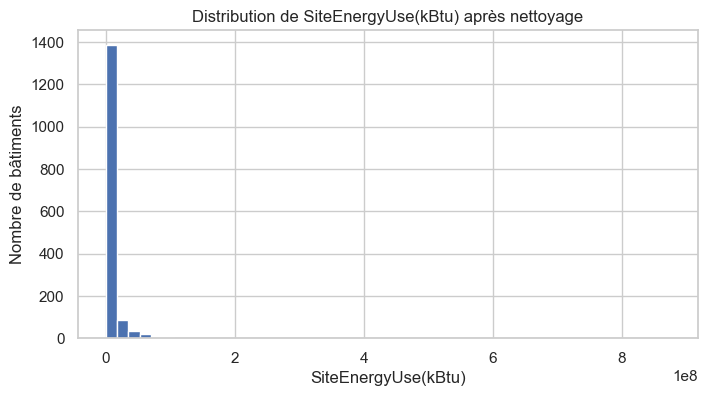

```python
plt.figure(figsize=(8, 4))
building_consumption["SiteEnergyUse(kBtu)"].hist(bins=50)
plt.title("Distribution de SiteEnergyUse(kBtu) après nettoyage")
plt.xlabel("SiteEnergyUse(kBtu)")
plt.ylabel("Nombre de bâtiments")
plt.show()
```

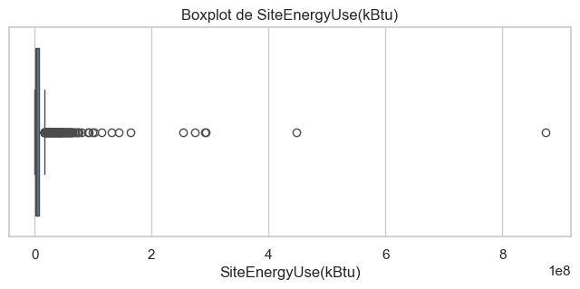

```python
plt.figure(figsize=(8, 3))
sns.boxplot(x=building_consumption["SiteEnergyUse(kBtu)"])
plt.title("Boxplot de SiteEnergyUse(kBtu)")
plt.xlabel("SiteEnergyUse(kBtu)")
plt.show()
```

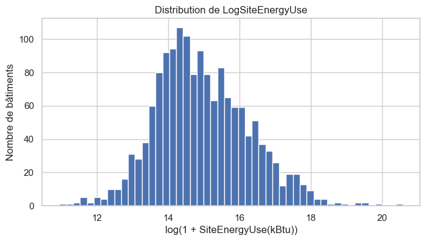

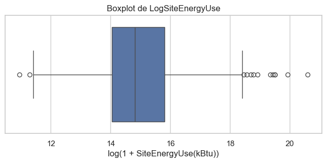

```python
# Création de la variable transformée
building_consumption["LogSiteEnergyUse"] = np.log1p(building_consumption["SiteEnergyUse(kBtu)"])

# Histogramme
plt.figure(figsize=(8, 4))
building_consumption["LogSiteEnergyUse"].hist(bins=50)
plt.title("Distribution de LogSiteEnergyUse")
plt.xlabel("log(1 + SiteEnergyUse(kBtu))")
plt.ylabel("Nombre de bâtiments")
plt.show()

# Boxplot
plt.figure(figsize=(8, 3))
sns.boxplot(x=building_consumption["LogSiteEnergyUse"])
plt.title("Boxplot de LogSiteEnergyUse")
plt.xlabel("log(1 + SiteEnergyUse(kBtu))")
plt.show()
```

**Interprétation :**

L’analyse conjointe de `SiteEnergyUse(kBtu)` avant et après transformation logarithmique met clairement en évidence l’intérêt de cette transformation.

Dans sa forme initiale, l’histogramme montre une distribution extrêmement asymétrique à droite : la très grande majorité des bâtiments présente des consommations relativement faibles, tandis qu’un petit nombre d’observations atteint des valeurs très élevées. Cette forte concentration des données près de zéro rend la lecture de la distribution difficile à l’échelle brute.

Le boxplot de la variable initiale confirme cette situation en faisant apparaître de nombreux outliers, parfois très éloignés du reste des observations. Cela traduit une forte dispersion et l’existence de bâtiments particulièrement énergivores, qui dominent visuellement la distribution.

Après application de la transformation logarithmique, la distribution devient beaucoup plus lisible et nettement moins asymétrique. L’histogramme de `LogSiteEnergyUse` présente une forme plus équilibrée, centrée sur un intervalle de valeurs plus resserré. Le boxplot associé montre que des valeurs atypiques subsistent, mais qu’elles sont désormais beaucoup moins extrêmes relativement au cœur de la distribution.

Ainsi, la transformation logarithmique ne supprime pas totalement les valeurs atypiques, mais elle réduit fortement leur influence et améliore la structure globale de la variable. `SiteEnergyUse(kBtu)` transformée devient donc plus adaptée aux analyses statistiques et aux modèles de prédiction, tout en conservant l’information portée par les écarts entre bâtiments.

## 10.2. Analyse univariée de `TotalGHGEmissions`

Nous poursuivons l’analyse univariée avec `TotalGHGEmissions`, qui représente les émissions totales de CO₂ des bâtiments.

Comme pour la consommation énergétique, l’objectif est de visualiser la forme de la distribution, de vérifier sa dispersion et de repérer d’éventuelles valeurs extrêmes après nettoyage.

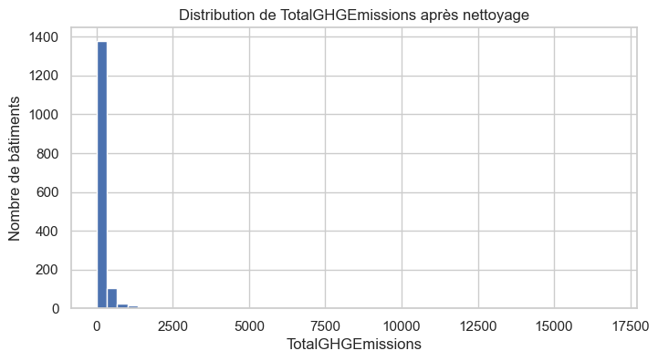

```python
plt.figure(figsize=(8, 4))
building_consumption["TotalGHGEmissions"].hist(bins=50)
plt.title("Distribution de TotalGHGEmissions après nettoyage")
plt.xlabel("TotalGHGEmissions")
plt.ylabel("Nombre de bâtiments")
plt.show()
```

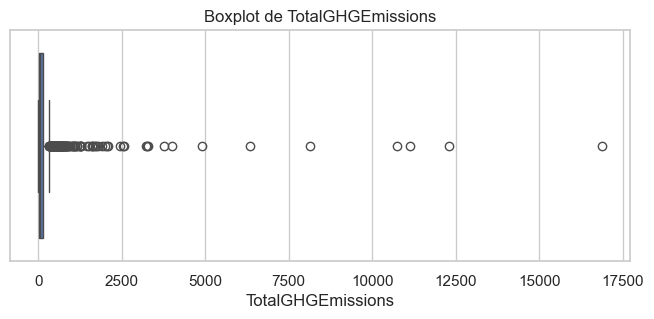

```python
plt.figure(figsize=(8, 3))
sns.boxplot(x=building_consumption["TotalGHGEmissions"])
plt.title("Boxplot de TotalGHGEmissions")
plt.xlabel("TotalGHGEmissions")
plt.show()
```

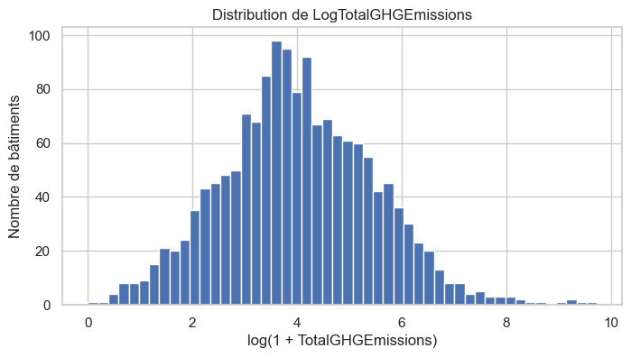

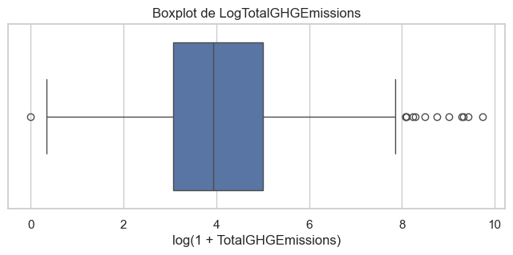

```python
# Création de la variable transformée
building_consumption["LogTotalGHGEmissions"] = np.log1p(building_consumption["TotalGHGEmissions"])

# Histogramme
plt.figure(figsize=(8, 4))
building_consumption["LogTotalGHGEmissions"].hist(bins=50)
plt.title("Distribution de LogTotalGHGEmissions")
plt.xlabel("log(1 + TotalGHGEmissions)")
plt.ylabel("Nombre de bâtiments")
plt.show()

# Boxplot
plt.figure(figsize=(8, 3))
sns.boxplot(x=building_consumption["LogTotalGHGEmissions"])
plt.title("Boxplot de LogTotalGHGEmissions")
plt.xlabel("log(1 + TotalGHGEmissions)")
plt.show()
```

**Interprétation :**

L’analyse de `TotalGHGEmissions` avant et après transformation logarithmique met en évidence une structure très proche de celle observée pour `SiteEnergyUse(kBtu)`.

Dans sa forme brute, l’histogramme montre une distribution extrêmement asymétrique à droite. La très grande majorité des bâtiments présente de faibles niveaux d’émissions, tandis qu’un petit nombre d’observations atteint des valeurs très élevées. Cette concentration massive des données sur les petites valeurs écrase visuellement le reste de la distribution et limite la lecture fine de sa forme.

Le boxplot de la variable initiale confirme cette forte dispersion en révélant de nombreux outliers, dont certains sont très éloignés du noyau principal des observations. Cela traduit la présence de bâtiments particulièrement émetteurs, qui exercent une influence importante sur la représentation globale de la variable.

Après application de la transformation logarithmique, la distribution devient nettement plus lisible et plus équilibrée. L’histogramme de `LogTotalGHGEmissions` présente une forme plus régulière, avec une concentration centrale mieux visible et une asymétrie fortement réduite, même si elle n’est pas totalement supprimée.

Le boxplot associé montre que quelques valeurs atypiques subsistent encore, mais qu’elles sont désormais beaucoup moins extrêmes relativement à l’ensemble des données. La dispersion paraît donc mieux maîtrisée et la structure générale de la variable devient plus exploitable.

Ainsi, la transformation logarithmique améliore fortement la représentation de `TotalGHGEmissions` en réduisant l’effet des valeurs extrêmes sans perdre l’information portée par les écarts entre bâtiments. La variable transformée apparaît donc plus adaptée aux analyses statistiques ultérieures ainsi qu’aux modèles de prédiction.

Les deux variables cibles présentant des comportements très similaires avant et après transformation, il sera pertinent de conserver cette logique pour la suite de l’étude, notamment lors de l’analyse des corrélations et de la phase de modélisation.

### 10.3. Comparaison visuelle des deux cibles avant et après transformation logarithmique

Afin de comparer les deux variables cibles de manière plus complète, nous représentons pour chacune d’elles la distribution et le boxplot à l’échelle initiale, puis après transformation logarithmique.

Cette visualisation permet d’évaluer l’effet de la transformation sur l’asymétrie, la dispersion et la présence de valeurs extrêmes, tout en comparant les comportements de `SiteEnergyUse(kBtu)` et `TotalGHGEmissions`.

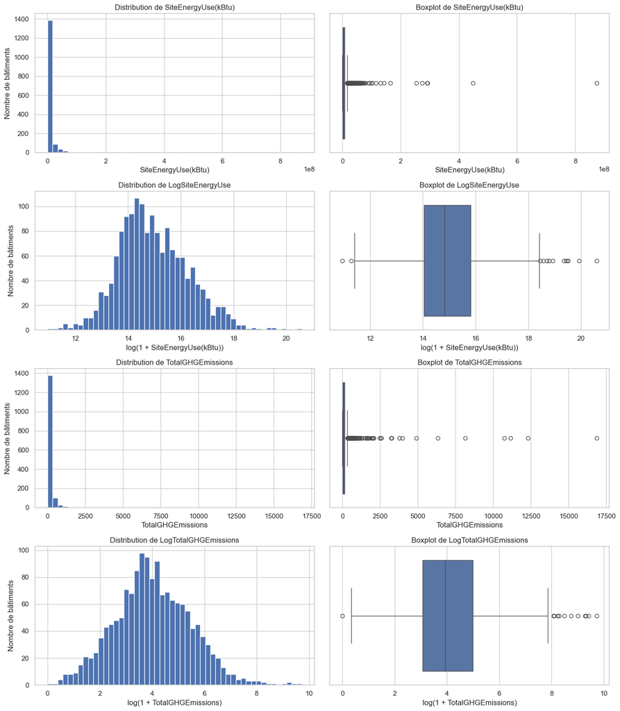

```python
import numpy as np
import matplotlib.pyplot as plt
import seaborn as sns

# Création des variables log si ce n'est pas déjà fait
building_consumption["LogSiteEnergyUse"] = np.log1p(building_consumption["SiteEnergyUse(kBtu)"])
building_consumption["LogTotalGHGEmissions"] = np.log1p(building_consumption["TotalGHGEmissions"])

fig, axes = plt.subplots(4, 2, figsize=(14, 16))

# 1. SiteEnergyUse brut - histogramme
building_consumption["SiteEnergyUse(kBtu)"].hist(bins=50, ax=axes[0, 0])
axes[0, 0].set_title("Distribution de SiteEnergyUse(kBtu)")
axes[0, 0].set_xlabel("SiteEnergyUse(kBtu)")
axes[0, 0].set_ylabel("Nombre de bâtiments")

# 2. TotalGHGEmissions brut - histogramme
building_consumption["TotalGHGEmissions"].hist(bins=50, ax=axes[2, 0])
axes[2, 0].set_title("Distribution de TotalGHGEmissions")
axes[2, 0].set_xlabel("TotalGHGEmissions")
axes[2, 0].set_ylabel("Nombre de bâtiments")

# 3. SiteEnergyUse brut - boxplot
sns.boxplot(x=building_consumption["SiteEnergyUse(kBtu)"], ax=axes[0, 1])
axes[0, 1].set_title("Boxplot de SiteEnergyUse(kBtu)")
axes[0, 1].set_xlabel("SiteEnergyUse(kBtu)")

# 4. TotalGHGEmissions brut - boxplot
sns.boxplot(x=building_consumption["TotalGHGEmissions"], ax=axes[2, 1])
axes[2, 1].set_title("Boxplot de TotalGHGEmissions")
axes[2, 1].set_xlabel("TotalGHGEmissions")

# 5. SiteEnergyUse log - histogramme
building_consumption["LogSiteEnergyUse"].hist(bins=50, ax=axes[1, 0])
axes[1, 0].set_title("Distribution de LogSiteEnergyUse")
axes[1, 0].set_xlabel("log(1 + SiteEnergyUse(kBtu))")
axes[1, 0].set_ylabel("Nombre de bâtiments")

# 6. TotalGHGEmissions log - histogramme
building_consumption["LogTotalGHGEmissions"].hist(bins=50, ax=axes[3, 0])
axes[3, 0].set_title("Distribution de LogTotalGHGEmissions")
axes[3, 0].set_xlabel("log(1 + TotalGHGEmissions)")
axes[3, 0].set_ylabel("Nombre de bâtiments")

# 7. SiteEnergyUse log - boxplot
sns.boxplot(x=building_consumption["LogSiteEnergyUse"], ax=axes[1, 1])
axes[1, 1].set_title("Boxplot de LogSiteEnergyUse")
axes[1, 1].set_xlabel("log(1 + SiteEnergyUse(kBtu))")

# 8. TotalGHGEmissions log - boxplot
sns.boxplot(x=building_consumption["LogTotalGHGEmissions"], ax=axes[3, 1])
axes[3, 1].set_title("Boxplot de LogTotalGHGEmissions")
axes[3, 1].set_xlabel("log(1 + TotalGHGEmissions)")

plt.tight_layout()
plt.show()
```

**Interprétation :**

La comparaison visuelle des deux cibles, avant et après transformation logarithmique, montre que `SiteEnergyUse(kBtu)` et `TotalGHGEmissions` présentent des comportements statistiques très proches.

À l’échelle initiale, les deux variables ont des distributions fortement asymétriques à droite, avec une forte concentration des observations sur de faibles valeurs et la présence de nombreux outliers. Cette structure traduit une dispersion importante et la présence de quelques bâtiments aux niveaux de consommation ou d’émissions particulièrement élevés.

Après transformation logarithmique, les distributions deviennent nettement plus lisibles et plus équilibrées. L’asymétrie reste présente, mais elle est fortement réduite, et les valeurs extrêmes exercent une influence visuelle beaucoup moins marquée. Les boxplots montrent que des observations atypiques subsistent, sans toutefois dominer autant la distribution qu’à l’échelle brute.

Cette comparaison confirme donc que les deux variables suivent une logique statistique similaire, aussi bien avant qu’après transformation. Elle justifie de les traiter de manière cohérente dans la suite de l’analyse, notamment pour l’étude de leur relation, l’analyse des corrélations et la construction éventuelle d’un modèle capable de prédire simultanément les deux cibles.

## 10.4. Analyse univariée des principales variables explicatives numériques

Dans cette sous-section, on s’intéresse à plusieurs variables numériques importantes pour la suite du projet :

`PropertyGFATotal` `NumberofFloors` `YearBuilt` `ENERGYSTARScore`

Ces variables sont intéressantes car elles décrivent :

- la taille du bâtiment ;
- sa structure ;
- son ancienneté ;
- son niveau de performance énergétique.

Avant de les relier aux cibles, il faut d’abord comprendre :

- leur distribution ;
- la présence éventuelle de valeurs extrêmes ;
- d’éventuelles incohérences.

### 10.4.1. Analyse univariée de `PropertyGFATotal`

La variable `PropertyGFATotal` représente la surface totale du bâtiment.  
Elle est potentiellement très importante, car la taille d’un bâtiment influence directement sa consommation énergétique et ses émissions de CO₂.

Nous cherchons ici à visualiser sa distribution et à repérer la présence éventuelle de très grandes surfaces.

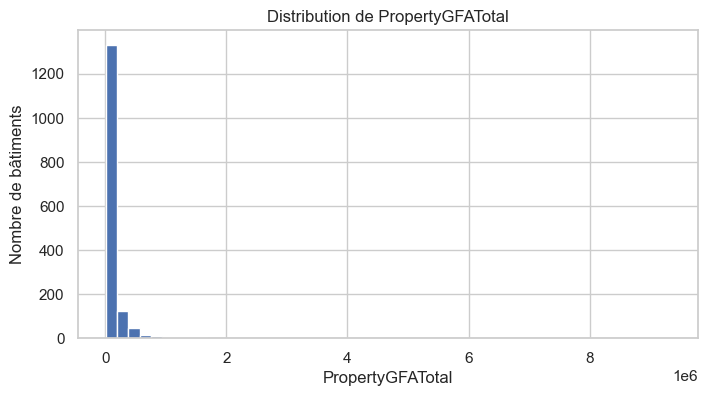

```python
plt.figure(figsize=(8, 4))
building_consumption["PropertyGFATotal"].hist(bins=50)
plt.title("Distribution de PropertyGFATotal")
plt.xlabel("PropertyGFATotal")
plt.ylabel("Nombre de bâtiments")
plt.show()
```

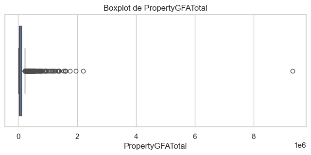

```python
plt.figure(figsize=(8, 3))
sns.boxplot(x=building_consumption["PropertyGFATotal"])
plt.title("Boxplot de PropertyGFATotal")
plt.xlabel("PropertyGFATotal")
plt.show()
```

**Interprétation :**

La variable `PropertyGFATotal` présente une distribution très asymétrique à droite. La majorité des bâtiments possède une surface totale relativement modérée, tandis qu’un petit nombre de bâtiments présente des surfaces extrêmement élevées.

Le boxplot confirme la présence de nombreux outliers, dont certains très éloignés du reste des observations.

Cette variable semble donc fortement dispersée, mais elle est aussi potentiellement très informative pour expliquer la consommation énergétique et les émissions de CO₂, car la taille d’un bâtiment influence directement ses besoins énergétiques.

### 10.4.2. Analyse univariée de `NumberofFloors`

La variable `NumberofFloors` indique le nombre d’étages du bâtiment.  
Elle apporte une information structurelle importante, qui peut être liée au volume du bâtiment et à sa consommation.

Nous cherchons ici à examiner la forme de sa distribution et à vérifier la présence de valeurs atypiques.

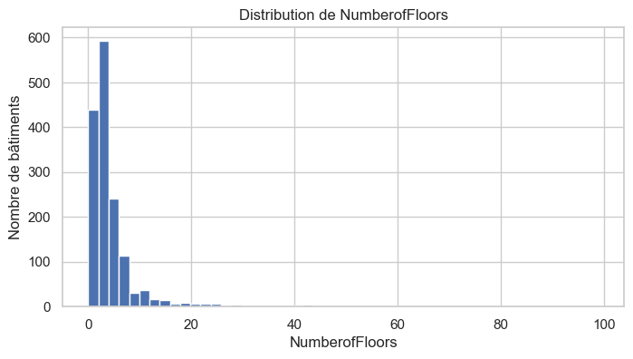

```python
plt.figure(figsize=(8, 4))
building_consumption["NumberofFloors"].hist(bins=50)
plt.title("Distribution de NumberofFloors")
plt.xlabel("NumberofFloors")
plt.ylabel("Nombre de bâtiments")
plt.show()
```

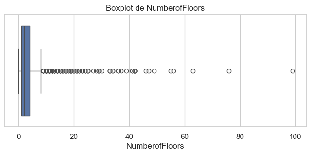

```python
plt.figure(figsize=(8, 3))
sns.boxplot(x=building_consumption["NumberofFloors"])
plt.title("Boxplot de NumberofFloors")
plt.xlabel("NumberofFloors")
plt.show()
```

**Interprétation :**

La variable `NumberofFloors` est fortement concentrée sur les petites valeurs, ce qui montre que la majorité des bâtiments du dataset possède peu d’étages.

Le boxplot met en évidence plusieurs outliers, avec quelques bâtiments extrêmement hauts. Cela indique que la variable est asymétrique à droite et comporte quelques cas structurellement atypiques.

Même si ces valeurs extrêmes sont rares, `NumberofFloors` reste une variable pertinente pour décrire la structure du bâtiment et potentiellement expliquer ses besoins énergétiques.

### 10.4.3. Analyse univariée de `YearBuilt`

La variable `YearBuilt` correspond à l’année de construction du bâtiment.  
Elle peut être importante, car l’ancienneté d’un bâtiment peut influencer ses performances énergétiques.

Nous cherchons ici à observer la répartition des années de construction et à repérer d’éventuelles concentrations sur certaines périodes.

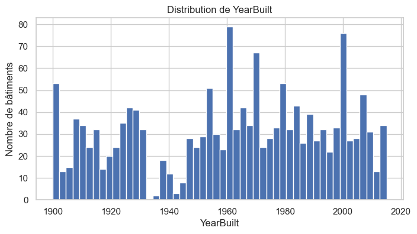

```python
plt.figure(figsize=(8, 4))
building_consumption["YearBuilt"].hist(bins=50)
plt.title("Distribution de YearBuilt")
plt.xlabel("YearBuilt")
plt.ylabel("Nombre de bâtiments")
plt.show()
```

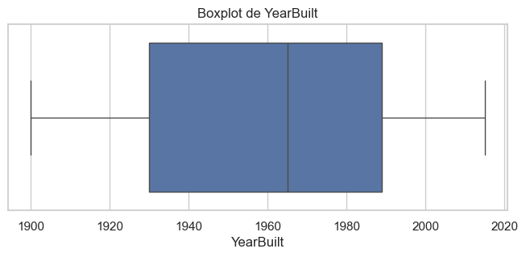

```python
plt.figure(figsize=(8, 3))
sns.boxplot(x=building_consumption["YearBuilt"])
plt.title("Boxplot de YearBuilt")
plt.xlabel("YearBuilt")
plt.show()
```

**Interprétation :**

La variable `YearBuilt` présente une répartition étendue sur plus d’un siècle, sans forte asymétrie ni valeurs extrêmes problématiques.

La distribution suggère que le dataset contient à la fois des bâtiments anciens et des bâtiments plus récents, ce qui est intéressant pour étudier l’effet de l’ancienneté sur la consommation énergétique et les émissions de CO₂.

Le boxplot ne met pas en évidence d’anomalie majeure, ce qui rend cette variable directement exploitable dans la suite de l’analyse.

### 10.4.4. Analyse univariée de `ENERGYSTARScore`

La variable `ENERGYSTARScore` mesure la performance énergétique du bâtiment sur une échelle standardisée.  
Elle peut être très informative pour expliquer les différences de consommation ou d’émissions entre bâtiments.

Nous cherchons ici à visualiser sa distribution parmi les observations renseignées.

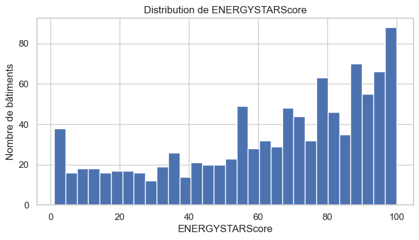

```python
plt.figure(figsize=(8, 4))
building_consumption["ENERGYSTARScore"].dropna().hist(bins=30)
plt.title("Distribution de ENERGYSTARScore")
plt.xlabel("ENERGYSTARScore")
plt.ylabel("Nombre de bâtiments")
plt.show()
```

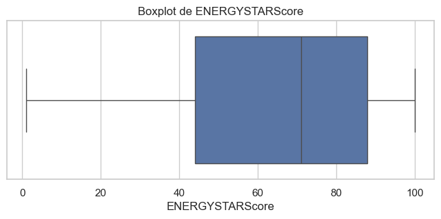

```python
plt.figure(figsize=(8, 3))
sns.boxplot(x=building_consumption["ENERGYSTARScore"].dropna())
plt.title("Boxplot de ENERGYSTARScore")
plt.xlabel("ENERGYSTARScore")
plt.show()
```

**Interprétation :**

La variable `ENERGYSTARScore` présente une distribution globalement concentrée vers les scores élevés, ce qui suggère qu’une part importante des bâtiments renseignés possède une performance énergétique relativement correcte.

Le boxplot ne met pas en évidence d’outliers majeurs, et la dispersion reste raisonnable.

Cette variable semble donc particulièrement intéressante pour la suite de l’analyse, car elle apporte une information directement liée à l’efficacité énergétique du bâtiment.

## 10.4.5. Vue d’ensemble des principales variables numériques

Afin d’avoir une vision synthétique des distributions des principales variables explicatives numériques, nous affichons leurs histogrammes et boxplots dans une figure d’ensemble.

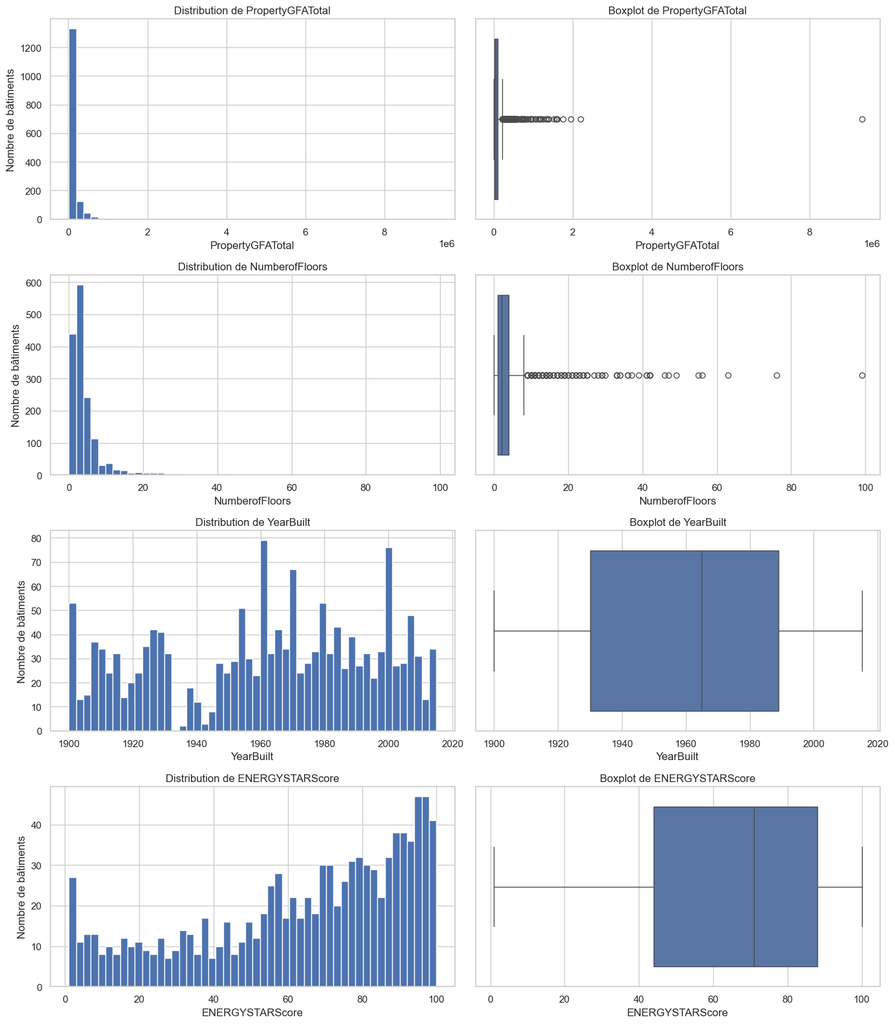

```python
fig, axes = plt.subplots(4, 2, figsize=(14, 16))

# PropertyGFATotal
building_consumption["PropertyGFATotal"].hist(bins=50, ax=axes[0, 0])
axes[0, 0].set_title("Distribution de PropertyGFATotal")
axes[0, 0].set_xlabel("PropertyGFATotal")
axes[0, 0].set_ylabel("Nombre de bâtiments")

sns.boxplot(x=building_consumption["PropertyGFATotal"], ax=axes[0, 1])
axes[0, 1].set_title("Boxplot de PropertyGFATotal")
axes[0, 1].set_xlabel("PropertyGFATotal")

# NumberofFloors
building_consumption["NumberofFloors"].hist(bins=50, ax=axes[1, 0])
axes[1, 0].set_title("Distribution de NumberofFloors")
axes[1, 0].set_xlabel("NumberofFloors")
axes[1, 0].set_ylabel("Nombre de bâtiments")

sns.boxplot(x=building_consumption["NumberofFloors"], ax=axes[1, 1])
axes[1, 1].set_title("Boxplot de NumberofFloors")
axes[1, 1].set_xlabel("NumberofFloors")

# YearBuilt
building_consumption["YearBuilt"].hist(bins=50, ax=axes[2, 0])
axes[2, 0].set_title("Distribution de YearBuilt")
axes[2, 0].set_xlabel("YearBuilt")
axes[2, 0].set_ylabel("Nombre de bâtiments")

sns.boxplot(x=building_consumption["YearBuilt"], ax=axes[2, 1])
axes[2, 1].set_title("Boxplot de YearBuilt")
axes[2, 1].set_xlabel("YearBuilt")

# ENERGYSTARScore
building_consumption["ENERGYSTARScore"].dropna().hist(bins=50, ax=axes[3, 0])
axes[3, 0].set_title("Distribution de ENERGYSTARScore")
axes[3, 0].set_xlabel("ENERGYSTARScore")
axes[3, 0].set_ylabel("Nombre de bâtiments")

sns.boxplot(x=building_consumption["ENERGYSTARScore"].dropna(), ax=axes[3, 1])
axes[3, 1].set_title("Boxplot de ENERGYSTARScore")
axes[3, 1].set_xlabel("ENERGYSTARScore")

plt.tight_layout()
plt.show()
```

**Interprétation globale :**

Les principales variables explicatives numériques présentent des comportements très différents :

- `PropertyGFATotal` et `NumberofFloors` sont fortement asymétriques et contiennent plusieurs outliers ;
- `YearBuilt` présente une répartition plus régulière, sans valeur extrême problématique ;
- `ENERGYSTARScore` est une variable bornée et relativement stable, potentiellement très informative pour la performance énergétique.

Cette diversité de distributions confirme l’intérêt d’une analyse exploratoire détaillée avant d’étudier les relations entre variables et de passer au feature engineering.

## Conclusion de la section 10.4

- À ce stade, on a une bonne compréhension des principales variables numériques :
- les variables de taille sont très asymétriques ;
- les variables structurelles ne se comportent pas toutes de la même manière ;
- certaines variables semblent naturellement plus “propres” que d’autres ;
- plusieurs d’entre elles paraissent déjà très prometteuses pour expliquer les deux cibles.

## 10.5. Analyse univariée des principales variables explicatives catégorielles

L’objectif de cette sous-section est de comprendre :

quelles catégories sont les plus représentées ; si certaines catégories dominent fortement le dataset ; si certaines modalités sont très rares ; quelles variables catégorielles seront pertinentes pour la suite de l’analyse et de la modélisation.

On va commencer par les variables les plus informatives :

`PrimaryPropertyType` `Neighborhood`

et on pourra aussi jeter un œil à `BuildingType` après filtrage, même si cette variable est maintenant beaucoup moins variée.

### 10.5.1. Analyse univariée de `PrimaryPropertyType`

La variable `PrimaryPropertyType` décrit l’usage principal du bâtiment (bureaux, hôtels, écoles, entrepôts, commerces, etc.).

Elle est potentiellement très importante, car le type d’activité exercée dans un bâtiment influence directement son profil énergétique et ses émissions de CO₂.

Nous cherchons ici à identifier les catégories les plus fréquentes et à évaluer l’hétérogénéité des usages représentés dans le dataset.

```python
#fréquences des catégories
building_consumption["PrimaryPropertyType"].value_counts().head(15)
```

```
PrimaryPropertyType
Small- and Mid-Sized Office    285
Other                          245
Warehouse                      185
Large Office                   169
Mixed Use Property             113
Retail Store                    85
Hotel                           75
Worship Facility                69
Distribution Center             53
K-12 School                     50
Supermarket / Grocery Store     40
Medical Office                  39
Self-Storage Facility           28
University                      24
Residence Hall                  21
Name: count, dtype: int64
```

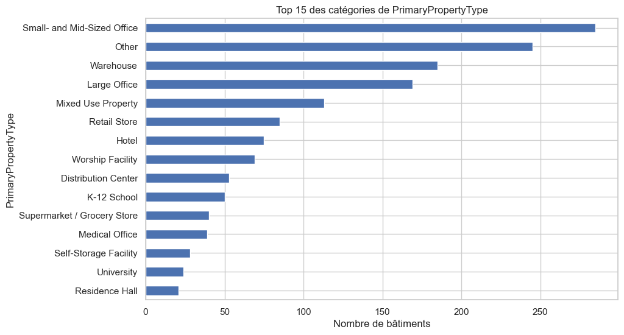

```python
#barplot des catégories les plus fréquentes
plt.figure(figsize=(10, 6))
building_consumption["PrimaryPropertyType"].value_counts().head(15).sort_values().plot(kind="barh")
plt.title("Top 15 des catégories de PrimaryPropertyType")
plt.xlabel("Nombre de bâtiments")
plt.ylabel("PrimaryPropertyType")
plt.show()
```

**Interprétation :**

La variable `PrimaryPropertyType` montre que le dataset est dominé par quelques usages principaux, en particulier les bureaux de taille petite ou moyenne, les entrepôts et les grands bureaux.

Cependant, les catégories restent variées : commerces, hôtels, écoles, bâtiments religieux ou encore bâtiments mixtes sont également représentés. Cette diversité confirme que le dataset couvre plusieurs profils énergétiques potentiellement très différents.

La catégorie `Other` est particulièrement fréquente, ce qui montre qu’une part non négligeable des bâtiments n’est pas décrite par un usage principal très précis. Malgré cette limite, `PrimaryPropertyType` reste une variable catégorielle importante pour la suite de l’analyse et de la modélisation.

### 10.5.2. Analyse univariée de `Neighborhood`

La variable `Neighborhood` indique le quartier dans lequel se situe le bâtiment.

Même si cette variable est moins directement liée au fonctionnement du bâtiment que `PrimaryPropertyType`, elle peut apporter une information utile sur le contexte urbain, la densité ou la structure du bâti.

Nous cherchons ici à repérer les quartiers les plus représentés dans le dataset.

```python
# fréquences des quartiers
building_consumption["Neighborhood"].value_counts().head(15)
```

```
Neighborhood
DOWNTOWN                 351
GREATER DUWAMISH         328
MAGNOLIA / QUEEN ANNE    144
LAKE UNION               143
NORTHEAST                117
EAST                     116
NORTHWEST                 74
BALLARD                   58
NORTH                     51
CENTRAL                   41
DELRIDGE                  36
SOUTHEAST                 31
SOUTHWEST                 31
North                      8
Ballard                    5
Name: count, dtype: int64
```

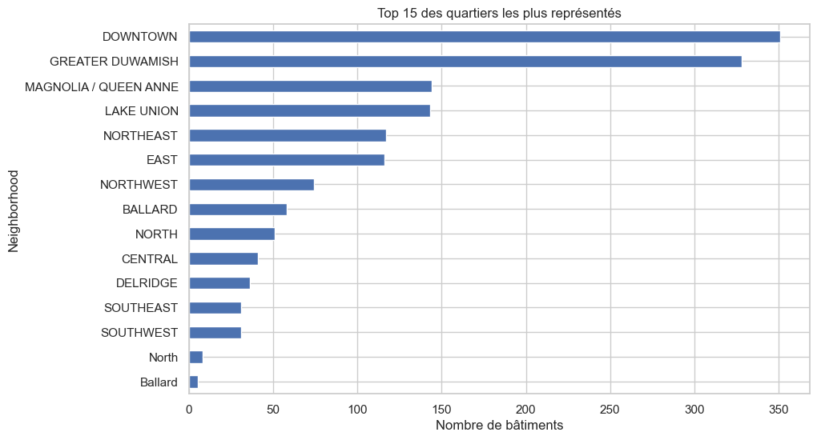

```python
# barplot des quartiers les plus fréquents
plt.figure(figsize=(10, 6))
building_consumption["Neighborhood"].value_counts().head(15).sort_values().plot(kind="barh")
plt.title("Top 15 des quartiers les plus représentés")
plt.xlabel("Nombre de bâtiments")
plt.ylabel("Neighborhood")
plt.show()
```

**Interprétation :**

La variable `Neighborhood` montre que les bâtiments du dataset sont inégalement répartis dans l’espace urbain. Les quartiers `DOWNTOWN` et `GREATER DUWAMISH` sont nettement surreprésentés, ce qui reflète probablement la concentration des bâtiments non résidentiels dans les zones centrales, commerciales ou industrielles.

La distribution géographique n’est donc pas homogène, ce qui suggère que la localisation pourrait jouer un rôle dans les comportements énergétiques.

On remarque également quelques incohérences d’écriture, comme `NORTH` / `North` ou `BALLARD` / `Ballard`, qui traduisent une légère absence de normalisation dans cette variable.

### 10.5.3. Vérification finale de `BuildingType`

Après le filtrage du périmètre non résidentiel, la variable `BuildingType` contient beaucoup moins de catégories qu’au départ.

Cette vérification permet simplement de confirmer les types de bâtiments encore présents dans le dataset final nettoyé.

```python
building_consumption["BuildingType"].value_counts(dropna=False)
```

```
BuildingType
NonResidential        1431
Nonresidential COS      81
Campus                  24
SPS-District K-12       10
Nonresidential WA        1
Name: count, dtype: int64
```

**Interprétation :**

Elle ne sert plus à définir le périmètre, car cela a déjà été fait, mais à rappeler qu’après nettoyage, le dataset final est composé uniquement de catégories compatibles avec le projet.

Après filtrage du périmètre non résidentiel et contrôle qualité, la variable `BuildingType` contient désormais uniquement des catégories compatibles avec l’objectif du projet.

La catégorie `NonResidential` domine très largement le dataset final, ce qui signifie que cette variable est devenue moins informative qu’au départ. Les catégories institutionnelles spécifiques (`Campus`, `SPS-District K-12`, `Nonresidential COS`, `Nonresidential WA`) restent présentes mais en effectifs beaucoup plus faibles.

Ainsi, `BuildingType` peut encore être conservée comme variable explicative, mais elle sera probablement moins discriminante que `PrimaryPropertyType`.

### 10.5.4. Vue d’ensemble des principales variables catégorielles

Afin d’obtenir une lecture synthétique des catégories les plus fréquentes, nous représentons côte à côte les principales modalités de `PrimaryPropertyType` et `Neighborhood`.

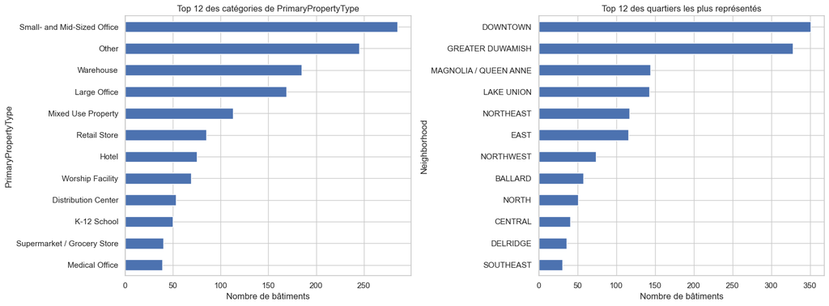

```python
fig, axes = plt.subplots(1, 2, figsize=(16, 6))

building_consumption["PrimaryPropertyType"].value_counts().head(12).sort_values().plot(
    kind="barh", ax=axes[0]
)
axes[0].set_title("Top 12 des catégories de PrimaryPropertyType")
axes[0].set_xlabel("Nombre de bâtiments")
axes[0].set_ylabel("PrimaryPropertyType")

building_consumption["Neighborhood"].value_counts().head(12).sort_values().plot(
    kind="barh", ax=axes[1]
)
axes[1].set_title("Top 12 des quartiers les plus représentés")
axes[1].set_xlabel("Nombre de bâtiments")
axes[1].set_ylabel("Neighborhood")

plt.tight_layout()
plt.show()
```

**Interprétation globale :**

Les variables catégorielles montrent que le dataset est à la fois :

- fonctionnellement hétérogène, avec plusieurs usages principaux représentés ;
- spatialement concentré, avec une forte présence de certains quartiers.

`PrimaryPropertyType` semble particulièrement importante pour expliquer les différences de consommation énergétique et d’émissions, tandis que `Neighborhood` apporte une information géographique complémentaire.

Ces variables devront donc être intégrées avec soin dans la suite de l’analyse et dans la préparation des modèles.

## 11. Analyse bivariée entre variables explicatives et variables cibles

Jusqu’ici, on a étudié les variables une par une. Maintenant, on veut comprendre comment certaines variables explicatives sont liées aux deux cibles :

`SiteEnergyUse(kBtu)` `TotalGHGEmissions`

Cette étape est essentielle car elle permet de :

détecter des relations visuelles ; voir si certaines variables semblent très explicatives ; repérer des structures non linéaires ; préparer les choix de feature engineering et de modélisation.

On va commencer par la variable la plus naturelle :

`PropertyGFATotal`

car la surface totale du bâtiment a de fortes chances d’influencer directement :

la consommation énergétique ; les émissions de CO₂.

## 11.1. Relation entre `PropertyGFATotal` et `SiteEnergyUse(kBtu)`

Nous commençons l’analyse bivariée par la relation entre la surface totale du bâtiment (`PropertyGFATotal`) et sa consommation énergétique totale (`SiteEnergyUse(kBtu)`).

Cette relation est importante à étudier, car on peut s’attendre à ce que les bâtiments les plus grands consomment davantage d’énergie.

L’objectif est ici de vérifier visuellement :

- s’il existe une relation croissante ;
- si cette relation semble linéaire ou non ;
- et si quelques observations extrêmes dominent le nuage de points.

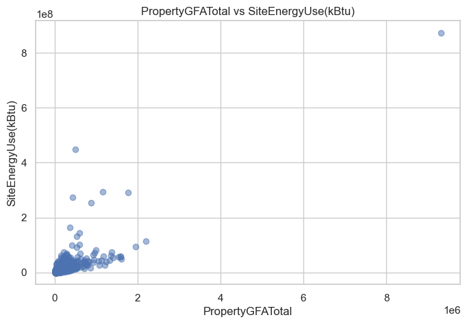

```python
plt.figure(figsize=(8, 5))
plt.scatter(
    building_consumption["PropertyGFATotal"],
    building_consumption["SiteEnergyUse(kBtu)"],
    alpha=0.5
)
plt.title("PropertyGFATotal vs SiteEnergyUse(kBtu)")
plt.xlabel("PropertyGFATotal")
plt.ylabel("SiteEnergyUse(kBtu)")
plt.show()
```

### Lecture complémentaire en échelle logarithmique

Comme `PropertyGFATotal` et `SiteEnergyUse(kBtu)` sont toutes deux très asymétriques, nous ajoutons une visualisation en échelle logarithmique afin de mieux lire la structure de la relation.

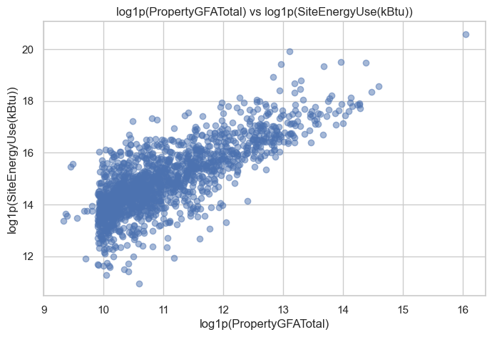

```python
plt.figure(figsize=(8, 5))
plt.scatter(
    np.log1p(building_consumption["PropertyGFATotal"]),
    np.log1p(building_consumption["SiteEnergyUse(kBtu)"]),
    alpha=0.5
)
plt.title("log1p(PropertyGFATotal) vs log1p(SiteEnergyUse(kBtu))")
plt.xlabel("log1p(PropertyGFATotal)")
plt.ylabel("log1p(SiteEnergyUse(kBtu))")
plt.show()
```

**Interprétation :**

Le nuage de points en échelle brute est fortement dominé par quelques valeurs extrêmes, ce qui rend la relation difficile à lire. On observe néanmoins une tendance générale croissante : les bâtiments les plus grands tendent à consommer davantage d’énergie.

La représentation en échelle logarithmique permet de mieux visualiser cette relation. Le nuage devient alors beaucoup plus structuré et met en évidence une relation positive quasi linéaire entre la surface du bâtiment et sa consommation énergétique.

Cela suggère que `PropertyGFATotal` est une variable explicative importante pour prédire `SiteEnergyUse(kBtu)`.

## 11.2. Relation entre `PropertyGFATotal` et `TotalGHGEmissions`

Nous poursuivons l’analyse bivariée avec la relation entre la surface totale du bâtiment (`PropertyGFATotal`) et les émissions totales de CO₂ (`TotalGHGEmissions`).

Comme pour la consommation énergétique, on peut s’attendre à ce que les bâtiments les plus grands soient globalement plus émetteurs. Nous vérifions ici si cette tendance apparaît clairement dans les données.

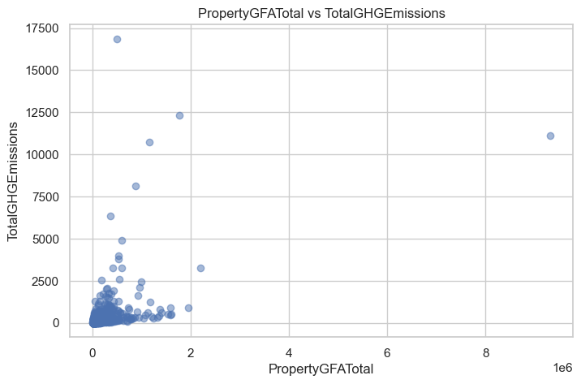

```python
plt.figure(figsize=(8, 5))
plt.scatter(
    building_consumption["PropertyGFATotal"],
    building_consumption["TotalGHGEmissions"],
    alpha=0.5
)
plt.title("PropertyGFATotal vs TotalGHGEmissions")
plt.xlabel("PropertyGFATotal")
plt.ylabel("TotalGHGEmissions")
plt.show()
```

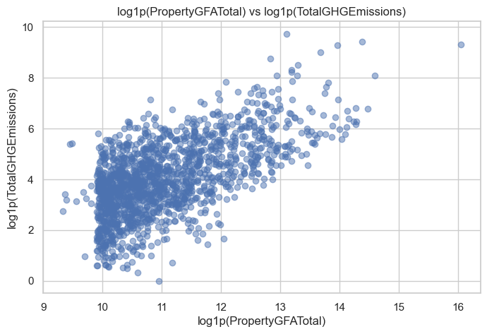

```python
# Variante en log
plt.figure(figsize=(8, 5))
plt.scatter(
    np.log1p(building_consumption["PropertyGFATotal"]),
    np.log1p(building_consumption["TotalGHGEmissions"]),
    alpha=0.5
)
plt.title("log1p(PropertyGFATotal) vs log1p(TotalGHGEmissions)")
plt.xlabel("log1p(PropertyGFATotal)")
plt.ylabel("log1p(TotalGHGEmissions)")
plt.show()
```

**Interprétation :**

Comme pour la consommation énergétique, le nuage de points en échelle brute est fortement influencé par quelques valeurs extrêmes, ce qui rend la lecture difficile.

En revanche, la représentation en échelle logarithmique met en évidence une relation croissante claire entre la surface totale du bâtiment et les émissions de CO₂. Le nuage de points devient plus structuré et suggère une relation quasi linéaire en log.

Cela confirme que `PropertyGFATotal` est également une variable explicative pertinente pour prédire `TotalGHGEmissions`.

**Conclusion :**

L’analyse bivariée montre que `PropertyGFATotal` est fortement liée aux deux variables cibles (`SiteEnergyUse(kBtu)` et `TotalGHGEmissions`).

Dans les deux cas, la relation est positive : les bâtiments les plus grands tendent à consommer plus d’énergie et à émettre davantage de CO₂.

La transformation logarithmique permet de révéler une relation plus structurée et quasi linéaire, ce qui suggère que **la taille du bâtiment** est un facteur explicatif majeur dans le problème étudié.

## 11.3. Relation entre SiteEnergyUse(kBtu) et TotalGHGEmissions

Cette sous-section est centrale, car elle permet d’étudier directement le lien entre les deux variables cibles du projet :

`SiteEnergyUse(kBtu)` : consommation énergétique totale ; `TotalGHGEmissions` : émissions totales de CO₂.

L’objectif est de vérifier :

- si les deux cibles évoluent dans le même sens ;
- si la relation est forte ou non ;
- si cette relation soutient l’idée d’un modèle multi-output prédisant les deux simultanément.

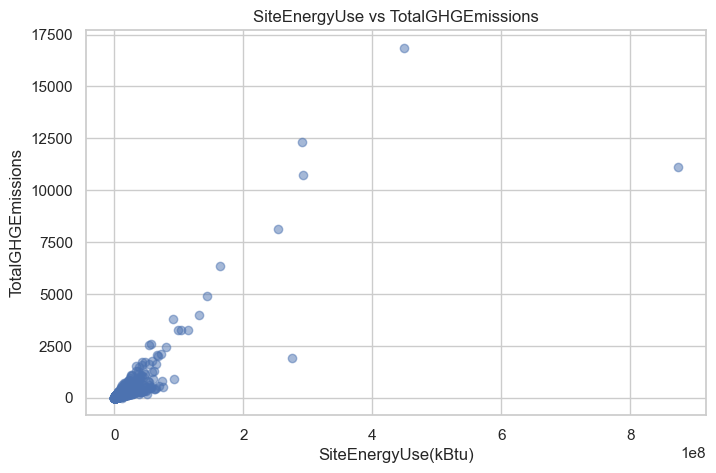

```python
plt.figure(figsize=(8, 5))
plt.scatter(
    building_consumption["SiteEnergyUse(kBtu)"],
    building_consumption["TotalGHGEmissions"],
    alpha=0.5
)
plt.title("SiteEnergyUse vs TotalGHGEmissions")
plt.xlabel("SiteEnergyUse(kBtu)")
plt.ylabel("TotalGHGEmissions")
plt.show()
```

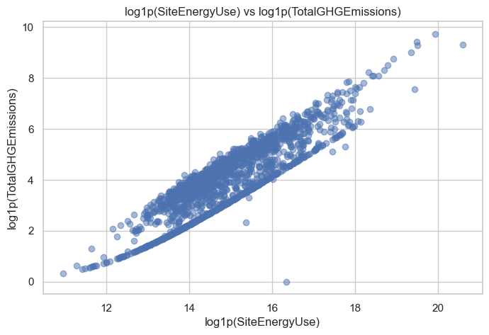

```python
plt.figure(figsize=(8, 5))
plt.scatter(
    np.log1p(building_consumption["SiteEnergyUse(kBtu)"]),
    np.log1p(building_consumption["TotalGHGEmissions"]),
    alpha=0.5
)
plt.title("log1p(SiteEnergyUse) vs log1p(TotalGHGEmissions)")
plt.xlabel("log1p(SiteEnergyUse)")
plt.ylabel("log1p(TotalGHGEmissions)")
plt.show()
```

**Interprétation :**

Le nuage de points entre `SiteEnergyUse(kBtu)` et `TotalGHGEmissions` met en évidence une relation croissante nette : les bâtiments qui consomment le plus d’énergie tendent aussi à être les plus émetteurs en CO₂.

En échelle brute, cette relation est visible mais partiellement écrasée par les valeurs extrêmes. La transformation logarithmique améliore fortement la lisibilité et fait apparaître une relation beaucoup plus structurée entre les deux cibles.

Cette observation est importante pour la suite du projet :

- elle montre que les deux variables cibles sont fortement liées ;
- elle justifie une analyse commune des deux sorties ;
- et elle soutient l’idée de tester un modèle multi-output capable de prédire simultanément la consommation énergétique et les émissions de CO₂.

La dispersion restante indique toutefois que les deux cibles ne sont pas parfaitement redondantes : les émissions dépendent aussi d’autres facteurs que la seule consommation énergétique.

**Conclusion intermédiaire :**

L’analyse bivariée réalisée jusqu’ici montre que certaines variables explicatives, comme `PropertyGFATotal`, entretiennent une relation claire avec les deux cibles. Elle montre aussi que `SiteEnergyUse(kBtu)` et `TotalGHGEmissions` sont elles-mêmes fortement liées.

La prochaine étape consiste à poursuivre l’analyse bivariée avec d’autres variables explicatives importantes, notamment `NumberofFloors` et `YearBuilt`, afin d’identifier d’autres relations utiles avant le feature engineering.

## 11.4. Relation entre `NumberofFloors` et les deux cibles

Nous examinons maintenant la relation entre le nombre d’étages (`NumberofFloors`) et les deux variables cibles.

Cette variable décrit la structure verticale du bâtiment et peut influencer sa consommation énergétique ainsi que ses émissions de CO₂.

### 11.4.1. `NumberofFloors` vs `SiteEnergyUse(kBtu)`

Nous commençons par étudier la relation entre le nombre d’étages et la consommation énergétique totale du bâtiment.

L’objectif est de voir si les bâtiments les plus hauts tendent à consommer davantage d’énergie, et si cette relation apparaît clairement dans les données.

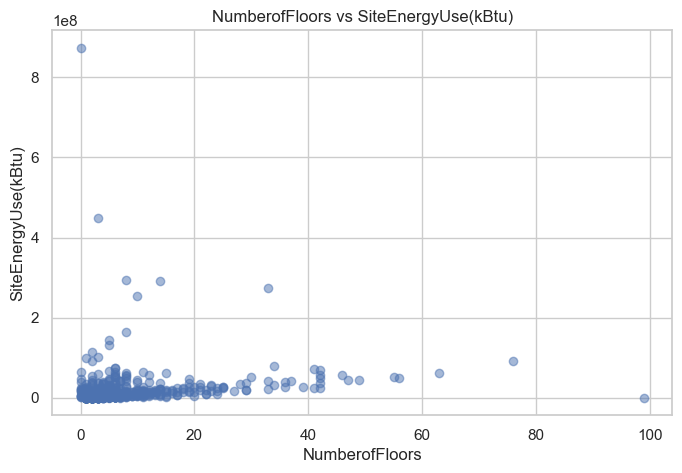

```python
plt.figure(figsize=(8, 5))
plt.scatter(
    building_consumption["NumberofFloors"],
    building_consumption["SiteEnergyUse(kBtu)"],
    alpha=0.5
)
plt.title("NumberofFloors vs SiteEnergyUse(kBtu)")
plt.xlabel("NumberofFloors")
plt.ylabel("SiteEnergyUse(kBtu)")
plt.show()
```

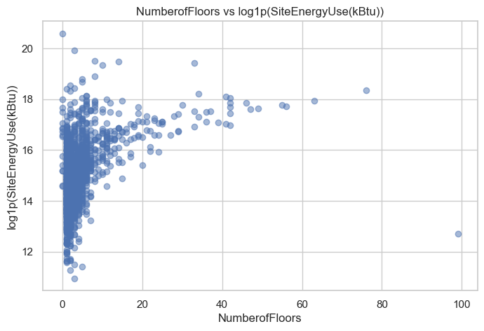

```python
# Variante utile en log sur la cible

plt.figure(figsize=(8, 5))
plt.scatter(
    building_consumption["NumberofFloors"],
    np.log1p(building_consumption["SiteEnergyUse(kBtu)"]),
    alpha=0.5
)
plt.title("NumberofFloors vs log1p(SiteEnergyUse(kBtu))")
plt.xlabel("NumberofFloors")
plt.ylabel("log1p(SiteEnergyUse(kBtu))")
plt.show()
```

**Interprétation :**

Le nuage de points entre `NumberofFloors` et `SiteEnergyUse(kBtu)` montre une tendance croissante globale, mais la relation reste assez dispersée.

La majorité des bâtiments possède peu d’étages, et pour un même nombre d’étages, on observe des niveaux de consommation très variés. La transformation logarithmique de la cible améliore la lisibilité, mais confirme que la relation reste plus faible et moins structurée que celle observée avec `PropertyGFATotal`.

Ainsi, `NumberofFloors` semble apporter une information utile sur la structure du bâtiment, mais son pouvoir explicatif paraît plus limité que celui de la surface totale.

### 11.4.2. `NumberofFloors` vs `TotalGHGEmissions`

Nous étudions ensuite la relation entre le nombre d’étages et les émissions totales de CO₂.

Comme pour la consommation énergétique, l’objectif est de vérifier si les bâtiments plus hauts tendent à être plus émetteurs.

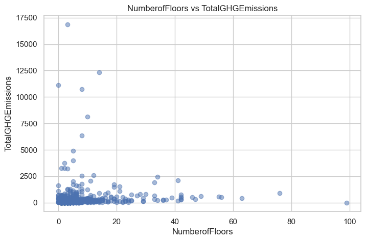

```python
plt.figure(figsize=(8, 5))
plt.scatter(
    building_consumption["NumberofFloors"],
    building_consumption["TotalGHGEmissions"],
    alpha=0.5
)
plt.title("NumberofFloors vs TotalGHGEmissions")
plt.xlabel("NumberofFloors")
plt.ylabel("TotalGHGEmissions")
plt.show()
```

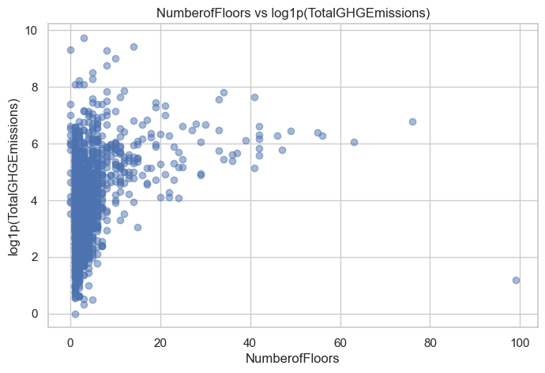

```python
# Variante utile en log sur la cible

plt.figure(figsize=(8, 5))
plt.scatter(
    building_consumption["NumberofFloors"],
    np.log1p(building_consumption["TotalGHGEmissions"]),
    alpha=0.5
)
plt.title("NumberofFloors vs log1p(TotalGHGEmissions)")
plt.xlabel("NumberofFloors")
plt.ylabel("log1p(TotalGHGEmissions)")
plt.show()
```

**Interprétation :**

Le nuage de points entre `NumberofFloors` et `TotalGHGEmissions` met en évidence une relation globale croissante, mais celle-ci reste très dispersée.

Même après transformation logarithmique des émissions, la tendance apparaît moins nette que pour la surface totale du bâtiment. Cela suggère que `NumberofFloors` contient une information structurelle utile, mais que cette variable seule n’explique qu’une partie limitée de la variabilité des émissions de CO₂.

Elle pourra donc être conservée dans la modélisation, mais plutôt comme variable complémentaire que comme facteur explicatif principal.

**Conclusion :**

L’analyse bivariée de `NumberofFloors` montre qu’il existe une relation croissante globale entre le nombre d’étages et les deux variables cibles, mais cette relation reste très dispersée.

Comparée à `PropertyGFATotal`, la variable `NumberofFloors` semble moins fortement liée à la consommation énergétique et aux émissions de CO₂. Elle conserve néanmoins un intérêt descriptif important, car elle apporte une information complémentaire sur la structure verticale du bâtiment.

Cette observation pourra justifier, dans la suite du projet, la conservation de `NumberofFloors` et éventuellement la création de variables dérivées combinant surface et hauteur du bâtiment.

**Conclusion intermédiaire :**

Les premières analyses bivariées montrent que la surface totale du bâtiment (`PropertyGFATotal`) est fortement liée aux deux cibles, tandis que le nombre d’étages (`NumberofFloors`) semble apporter une information plus secondaire mais néanmoins utile.

La prochaine étape consiste à examiner la variable `YearBuilt`, afin de vérifier si l’ancienneté du bâtiment entretient elle aussi une relation avec la consommation énergétique et les émissions de CO₂.